# Lab 07

In this lab you will:

- Explore some details for making plots
- Work with polynomial models

## Plots

We will continue working with the Google Trend dataset for R and Python. Recall the dataset we obtained contains the following variables:

- **week**: beginning date of the week (recent 5 years)
- **python**: trend of the search term **Data science Python**
- **r**: trend of the search term **Data science r**

Read the data.

```r
data_science <- read.csv("data_science.csv")
# convert string to date object
data_science$week <- as.Date(data_science$week, "%Y-%m-%d")
# create a numeric column representing the time
data_science$time <- as.numeric(data_science$week)
data_science$time <- data_science$time - data_science$time[1] + 1
```

### Function `plot`

The function `plot` is the most standard plotting function in R. When taking only one vector, it plots the vector against the index vector.

[figure not shown]

When taking two vectors, it plots the scatter plot.

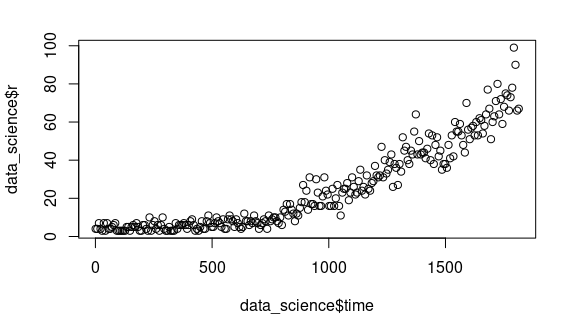

```r
plot(data_science$time, data_science$r)
```

```r
#tidyverse
data_science %>% ggplot()+geom_point(aes(x=time, y=r))
```

```
Error in data_science %>% ggplot() : could not find function "%>%"
```

The `plot` function can also accept a data frame as the parameter. And it plots all variables against each other.

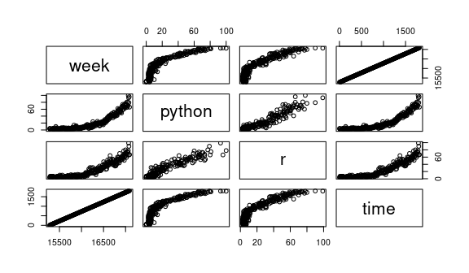

```r
plot(data_science)
```

### Low-level graphics functions

The `plot` function introduced above is a high-level plot function, which produces complete plots. There are also low-level functions that add further outputs to an existing plot. You have already seen some high-level functions such as `hist`, `boxplot` and `curve`. `lines` is a low-level function which can not be called directly.

Commenly used low-level functions includes:

- `points(x, y)`: Adds points to the current plot. `x` and `y` are vectors of coordinates.
- `lines(x, y)`: Add line to the current plot by joining the points with line segments.
- `text(x, y, labels, ...)`: Add text to a plot at points given by x, y.
- `abline(a, b)`: Adds a line of slope b and intercept a to the current plot.
- `abline(h=y)`: Adds a horizontal line.
- `abline(v=x)`: Adds a vertical line.
- `legend(x, y, legend, ...,lty = c())`: Add legends to plots

```r
curve(dnorm, xlim = c(-3, 3), ylim = c(0, 0.5))  # create a plot for the density of normal distribution
lines(density(rnorm(1000)), col = "red") # add a line (kernel density estimation) to the plot created
```

```r
abline(v=qnorm(0.025)) # add a vertical line (0.025 quanitle of standrad normal distribution)
abline(v=qnorm(0.975)) # add a vertical line (0.975 quanitle of standrad normal distribution)
```

```r
text(-2, 0.3, "0.025 quantile") # add text
text(2, 0.3, "0.975 quantile") # add text
```

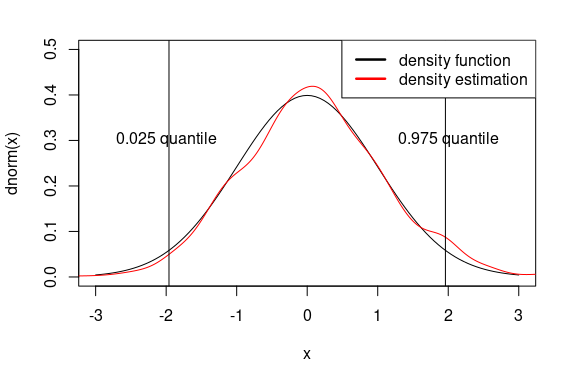

```r
legend("topright", c("density function", "density estimation"),
       lwd=c(2.5,2.5), # Line widths in the legend
       col=c("black", "red")) # Add legend
```

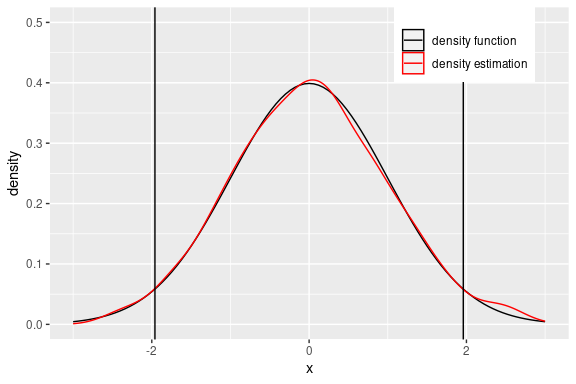

```r
#tidyverse
ggplot(data = data.frame(data = rnorm(1000)))+
        stat_function(fun = dnorm, mapping=aes(color = 'density function'))+
        geom_density(aes(x=data, color = 'density estimation'))+
        geom_vline(xintercept=qnorm(0.025))+
        geom_vline(xintercept=qnorm(0.975))+
        scale_colour_manual("",
                      breaks = c("density function", "density estimation"),
                      values = c("black", "red"))+
        xlab("x")+
        xlim(-3,3)+
        ylim(0,0.5)+
        theme(legend.position = c(0.8, 0.9))
```

### par()

The par() function is used to access and modify the list of graphics parameters. For example, to put several plots in the same window, use `par(mfrow = c(a, b))`. `a` is the number of rows and `b` is the number of columns. This command will allow you to plot `a*b` plots in one window.

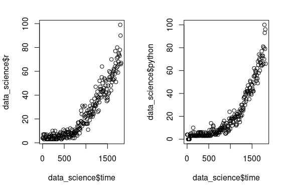

```r
library(tidyr)

par(mfrow=c(1, 2))
plot(data_science$time, data_science$r)
plot(data_science$time, data_science$python)
```

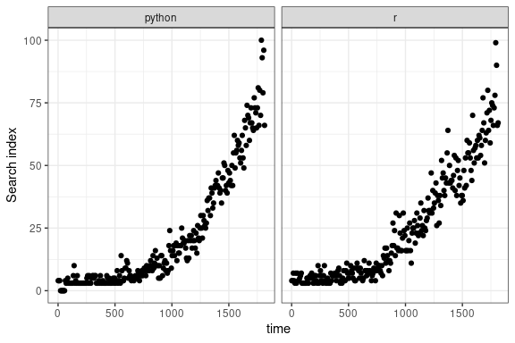

```r
#tidyverse

data_wide =  pivot_longer(data_science,
    cols = c(r, python),
    names_to = "Language",
    values_to = "Search index")

ggplot(data_wide, aes(x = time, y = `Search index`)) +
    geom_point() + facet_wrap(. ~ Language) +
    theme_bw()
```

### patchwork

There is a useful package to combine separate ggplots into the same graphic, “patchwork”.

```r
# Uncomment the following lines to install the packages
# install.packages("devtools")
# devtools::install_github("thomasp85/patchwork")
```

```r
library(ggplot2)
library(patchwork)

p1 <- ggplot(mtcars) + geom_point(aes(mpg, disp))
p2 <- ggplot(mtcars) + geom_boxplot(aes(gear, disp, group = gear))

p1 + p2
```

[output not shown]

```r
p3 <- ggplot(mtcars) + geom_smooth(aes(disp, qsec), formula = 'y~x' ,method = 'loess')
p4 <- ggplot(mtcars) + geom_bar(aes(carb))


(p1 | p2 | p3) /
      p4

(p1 | p2)/
  (p3 | p4)
```

[output not shown]

Other functions or packages for arranging ggplots: gridExtra::grid.arrange() and cowplot::plot_grid.

# Polynomial models

## Exercise 1

As you may discover, the linear model is not quite good for your dataset. In this exercise, you will fit a cubic curve to the data (use time to predict `r` and `python`).

1. Fit the cubic model.

```r
# Insert your code here and save your fitted model as
# `python.poly` and `r.poly`
# python.poly <-
# summary(python.poly)
# r.poly <-
# summary(r.poly)
```

2. In the fitting for `r` and `python` search index, which of the following term is significant (not equal to zero)?

```r
# Uncomment the line of your answer for this question: (r)
# intercept.r.sig <- TRUE
# time.r.sig <- TRUE
# time.r.square.sig <- TRUE
# time.r.cubic.sig <- TRUE
```

```r
# Uncomment the line of your answer for this question: (python)
# intercept.python.sig <- TRUE
# time.python.sig <- TRUE
# time.python.square.sig <- TRUE
# time.python.cubic.sig <- TRUE
```

3. Plot the scatter plot and the fitted line. Color the groups with red and blue. How will you describe the trend of r search and python search?

```r
# Insert your code here for plotting
```

## Reading - Caveat

Google trend seems so powerful and accessible. However, when analyzing some topics, we would rather not to use it. Why? Consider the following two examples.

### Global Warming & Pirates

Back to 2008, there is an obvious negative correlation between [global warming and pirate](https://www.google.com/trends/explore?date=2008-02-01%202008-04-30&q=global%20warming,pirates) searching, which may just be a coincidence. If you fit a linear model, the coefficients are significant.

```r
pirate <- read.csv("pirate.csv")
pirate$Day <- as.Date(pirate$Day, "%Y-%m-%d")
data_science$time <- as.numeric(data_science$week)
data_science$time <- as.numeric(data_science$week) - as.numeric(data_science$week)[1]
```

```r
plot(unclass(pirate$Day), pirate$pirates, cex = 0.5, col = "blue4",
     xlab = "Time", ylab = "Relative Trend", ylim = c(0, 100),
     main = "Google trend of priate and global warming", xaxt='n')
axis(1, at = pirate$Day[c(1, 30, 61, 90)],
     labels = as.character(pirate$Day)[c(1, 30, 61, 90)])
points(pirate$Day, pirate$global.warming, cex = 0.5, col = "red4")
lines(pirate$Day, pirate$pirates, col = "blue")
lines(pirate$Day, pirate$global.warming, col = "red")
legend("topright", legend = c("pirate", "global warming"),
       fill = c("blue4", "red4"))
```

[output not shown]

```r
pirate.lm <- lm(global.warming ~ pirates, data = pirate)

plot(pirate$pirates, pirate$global.warming, cex = 0.5, col = "blue4",
     xlab = "pirates", ylab = "global warming",
     main = "Google trend of pirate and gobal warming")
abline(pirate.lm)

cor(pirate$pirates, pirate$global.warming)
```

[output not shown]

```r
summary(pirate.lm)
```

[output not shown]

### The Failure of Google Flu Trend

[Google Flu Trend](https://www.google.org/flutrends/about/) was first launched in 2008 (The Google research paper: [Detecting influenza epidemics using search engine query data](http://static.googleusercontent.com/media/research.google.com/zh-CN//archive/papers/detecting-influenza-epidemics.pdf)). It was widely recognized an exciting event in the big data application In the 2009 flu pandemic, Google Flu Trends tracked information about flu in the United States. In February 2010, the CDC (the U.S. Centers for Disease Control and Prevention) identified influenza cases spiking in the mid-Atlantic region of the United States. However, Google’s data of search queries about flu symptoms was able to show that same spike two weeks prior to the CDC report being released.

The model was initially based on the flu data from 2003-2008. Google Flu Trend prediction performs well at the beginning. However, it’s been wrong since August 2011. The subsequent report continuously overestimates the flu prevalence. And now Google Flu Trends is no longer publishing current estimates of Flu based on search patterns.

In a Science article, a team of researchers described Google Flu Trend as “Big Data Hubris”:

“The core challenge is that most big data that have received popular attention are not the output of instruments designed to produce valid and reliable data amenable for scientific analysis.”

```r
flu <- read.csv("flu.csv", stringsAsFactors = FALSE)
flu$Date <- as.Date(flu$Date)
```

```r
plot(flu$Date, flu$California,
     type = "o", cex = 0.4,
     xlab="Age (days)",
     ylab="Circumference (mm)" )
```

[output not shown]

Reference and further reading:

- [The Parable of Google Flu: Traps in Big Data Analysis](http://science.sciencemag.org/content/343/6176/1203.figures-only)
- [Google Flu Trends’ Failure Shows Good Data > Big Data](https://hbr.org/2014/03/google-flu-trends-failure-shows-good-data-big-data)
- [Google Flu Trend](https://en.wikipedia.org/wiki/Google_Flu_Trends#cite_note-pcworld-4)

# LOESS: Local Polynomial Regression Fitting

There are several options in `R` for fitting a loess.

The function `loess.smooth()` returns a list with the smoothed data coordinates:

```r
loess.results <- loess.smooth(x = data_science$week, y = data_science$r)
loess.results
plot(loess.results$x, loess.results$y)
```

[output not shown]

Though `loess.smooth()` is convenient for plotting the smoothed fit, there is also `scatter.smooth()`, which prints both the scatter plot and the smoothed fit with just one line of code.

```r
scatter.smooth(x=data_science$time,y=data_science$r)
```

[output not shown]

Using `ggplot2`, we have

```r
data_science %>% ggplot(aes(
    x = time, y = r
)) + geom_point(size = 0.7) +
    geom_smooth(
        method = 'loess', span = 2/3,
        formula = y ~ poly(x, degree = 1),
        se = F) +
    theme_bw()
```

[output not shown]

To do prediction using a LOESS model, there is function `loess()`, which has similar usage as the `lm()` function. Notice the default smoothing parameter for `loess.smooth(span = 2/3, degree = 1)` and `loess(span = 0.75, degree = 2)` are different.

```r
loess.fitted <- loess(r~time, data = data_science)
summary(loess.fitted)
```

[output not shown]

```r
predict(loess.fitted, data.frame(time = c(1000, 1500)))
```

[output not shown]

## Exercise 2

Follow the steps below to create a plot:

1. Plot a scatter plot of `week` versus `r` and `week` versus `python` in the same pane; distinguish `r` from `python` by color.
2. Overlay the scatter plots with a LOESS smoothing line for both `r` and `python` appropriately matched colors.
3. Make sure that a legend is included in the plot.

Your plot should look something like the following:

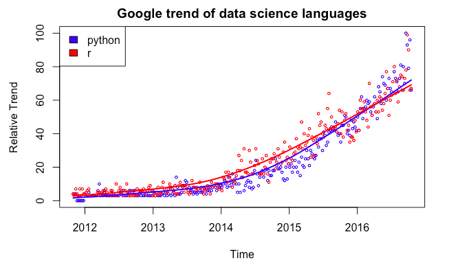

```r
# Insert your code here
```